# Video Game Sales Data Analysis And Sales Prediction

## **CONTENT :**

1. Basic Overview
2. Data Cleaning  
   2.1.Top 100 Video Games  
   2.2.Genre and Platform  
   2.3.Genre and Region
3. Sales Prediction  
   3.1.Basic Import  
   3.2.Data Processing  
   3.2.Different Classifier

## **1. Basic Overview**

#### 数据集选择 Video Game Sales：vgsales.csv 数据集包括（游戏排名，游戏名称，各地区销售额等）

#### 编程语言：python

首先导入所需各类依赖包：

```python
import numpy as np # linear algebra
import pandas as pd # data processing, CSV file I/O (e.g. pd.read_csv)
#import plotly.plotly as py
from plotly.offline import init_notebook_mode, iplot
init_notebook_mode(connected=True)
import plotly.graph_objs as go
from plotly.tools import FigureFactory as ff # 后序话散点矩阵图
import matplotlib.pyplot as plt
import seaborn as sns

import warnings # 忽略warnings
warnings.filterwarnings("ignore")
```

## **2. Data Cleaning**

```python
vgsales = pd.read_csv("vgsales.csv")
```

```python
d = vgsales.head(5)
colorscale = "YlOrRd"
table = ff.create_table(d, colorscale=colorscale)
for i in range(len(table.layout.annotations)):
    table.layout.annotations[i].font.size = 9
    table.layout.annotations[i].font.color = 'black'
iplot(table)
```

[interactive chart not shown]

```python
vgsales.tail(30)
```

|  | Rank | Name | Platform | Year | Genre | Publisher | NA_Sales | EU_Sales | JP_Sales | Other_Sales | Global_Sales |
| --- | --- | --- | --- | --- | --- | --- | --- | --- | --- | --- | --- |
| 16568 | 16571 | XI Coliseum | PSP | 2006.0 | Puzzle | Sony Computer Entertainment | 0.00 | 0.00 | 0.01 | 0.0 | 0.01 |
| 16569 | 16572 | Resident Evil 4 HD | XOne | 2016.0 | Shooter | Capcom | 0.01 | 0.00 | 0.00 | 0.0 | 0.01 |
| 16570 | 16573 | Farming 2017 - The Simulation | PS4 | 2016.0 | Simulation | UIG Entertainment | 0.00 | 0.01 | 0.00 | 0.0 | 0.01 |
| 16571 | 16574 | Grisaia no Kajitsu: La Fruit de la Grisaia | PSP | 2013.0 | Adventure | Prototype | 0.00 | 0.00 | 0.01 | 0.0 | 0.01 |
| 16572 | 16575 | Scarlett: Nichijou no Kyoukaisen | PS2 | 2008.0 | Adventure | Kadokawa Shoten | 0.00 | 0.00 | 0.01 | 0.0 | 0.01 |
| 16573 | 16576 | Mini Desktop Racing | Wii | 2007.0 | Racing | Popcorn Arcade | 0.01 | 0.00 | 0.00 | 0.0 | 0.01 |
| 16574 | 16577 | Yattaman Wii: BikkuriDokkiri Machine de Mou Ra... | Wii | 2008.0 | Racing | Takara Tomy | 0.00 | 0.00 | 0.01 | 0.0 | 0.01 |
| 16575 | 16578 | Neo Angelique Special | PSP | 2008.0 | Adventure | Tecmo Koei | 0.00 | 0.00 | 0.01 | 0.0 | 0.01 |
| 16576 | 16579 | Rugby Challenge 3 | XOne | 2016.0 | Sports | Alternative Software | 0.00 | 0.01 | 0.00 | 0.0 | 0.01 |
| 16577 | 16580 | Damnation | PC | 2009.0 | Shooter | Codemasters | 0.00 | 0.01 | 0.00 | 0.0 | 0.01 |
| 16578 | 16581 | Outdoors Unleashed: Africa 3D | 3DS | 2011.0 | Sports | Mastiff | 0.01 | 0.00 | 0.00 | 0.0 | 0.01 |
| 16579 | 16582 | PGA European Tour | N64 | 2000.0 | Sports | Infogrames | 0.01 | 0.00 | 0.00 | 0.0 | 0.01 |
| 16580 | 16583 | Real Rode | PS2 | 2008.0 | Adventure | Kadokawa Shoten | 0.00 | 0.00 | 0.01 | 0.0 | 0.01 |
| 16581 | 16584 | Fit & Fun | Wii | 2011.0 | Sports | Unknown | 0.00 | 0.01 | 0.00 | 0.0 | 0.01 |
| 16582 | 16585 | Planet Monsters | GBA | 2001.0 | Action | Titus | 0.01 | 0.00 | 0.00 | 0.0 | 0.01 |
| 16583 | 16586 | Carmageddon 64 | N64 | 1999.0 | Action | Virgin Interactive | 0.01 | 0.00 | 0.00 | 0.0 | 0.01 |
| 16584 | 16587 | Bust-A-Move 3000 | GC | 2003.0 | Puzzle | Ubisoft | 0.01 | 0.00 | 0.00 | 0.0 | 0.01 |
| 16585 | 16588 | Breach | PC | 2011.0 | Shooter | Destineer | 0.01 | 0.00 | 0.00 | 0.0 | 0.01 |
| 16586 | 16589 | Secret Files 2: Puritas Cordis | DS | 2009.0 | Adventure | Deep Silver | 0.00 | 0.01 | 0.00 | 0.0 | 0.01 |
| 16587 | 16590 | Mezase!! Tsuri Master DS | DS | 2009.0 | Sports | Hudson Soft | 0.00 | 0.00 | 0.01 | 0.0 | 0.01 |
| 16588 | 16591 | Mega Brain Boost | DS | 2008.0 | Puzzle | Majesco Entertainment | 0.01 | 0.00 | 0.00 | 0.0 | 0.01 |
| 16589 | 16592 | Chou Ezaru wa Akai Hana: Koi wa Tsuki ni Shiru... | PSV | 2016.0 | Action | dramatic create | 0.00 | 0.00 | 0.01 | 0.0 | 0.01 |
| 16590 | 16593 | Eiyuu Densetsu: Sora no Kiseki Material Collec... | PSP | 2007.0 | Role-Playing | Falcom Corporation | 0.00 | 0.00 | 0.01 | 0.0 | 0.01 |
| 16591 | 16594 | Myst IV: Revelation | PC | 2004.0 | Adventure | Ubisoft | 0.01 | 0.00 | 0.00 | 0.0 | 0.01 |
| 16592 | 16595 | Plushees | DS | 2008.0 | Simulation | Destineer | 0.01 | 0.00 | 0.00 | 0.0 | 0.01 |
| 16593 | 16596 | Woody Woodpecker in Crazy Castle 5 | GBA | 2002.0 | Platform | Kemco | 0.01 | 0.00 | 0.00 | 0.0 | 0.01 |
| 16594 | 16597 | Men in Black II: Alien Escape | GC | 2003.0 | Shooter | Infogrames | 0.01 | 0.00 | 0.00 | 0.0 | 0.01 |
| 16595 | 16598 | SCORE International Baja 1000: The Official Game | PS2 | 2008.0 | Racing | Activision | 0.00 | 0.00 | 0.00 | 0.0 | 0.01 |
| 16596 | 16599 | Know How 2 | DS | 2010.0 | Puzzle | 7G//AMES | 0.00 | 0.01 | 0.00 | 0.0 | 0.01 |
| 16597 | 16600 | Spirits & Spells | GBA | 2003.0 | Platform | Wanadoo | 0.01 | 0.00 | 0.00 | 0.0 | 0.01 |

让我们先来看看数据集中各属性的数据类型以及缺失值情况

```python
vgsales.info()
```

```
<class 'pandas.core.frame.DataFrame'>
RangeIndex: 16598 entries, 0 to 16597
Data columns (total 11 columns):
 #   Column        Non-Null Count  Dtype
---  ------        --------------  -----
 0   Rank          16598 non-null  int64
 1   Name          16598 non-null  object
 2   Platform      16598 non-null  object
 3   Year          16327 non-null  float64
 4   Genre         16598 non-null  object
 5   Publisher     16540 non-null  object
 6   NA_Sales      16598 non-null  float64
 7   EU_Sales      16598 non-null  float64
 8   JP_Sales      16598 non-null  float64
 9   Other_Sales   16598 non-null  float64
 10  Global_Sales  16598 non-null  float64
dtypes: float64(6), int64(1), object(4)
memory usage: 1.4+ MB
```

根据上述该数据集的信息可以看到在这个数据集中共有11列，他们的名称和代表内容如下所示：

- **Rank** - 总销售额排名, integer
- **Name** - 游戏名称, object
- **Platform** - 游戏发布平台 (i.e. PC,PS4, etc.), object
- **Year** - 游戏发布年份, float
- **Genre** - 游戏类型 ,object
- **Publisher** - 游戏发行商, object
- **NA_Sales** - 北美销售额 (百万计), float64
- **EU_Sales** - 欧洲销售额 (百万计), float64
- **JP_Sales** - 日本销售额 (百万计), float64
- **Other_Sales** - 在世界其他地方的销售额 (百万计), float64
- **Global_Sales** - 全球销售额, float64

```python
vgsales.isnull().sum()
```

```
Rank              0
Name              0
Platform          0
Year            271
Genre             0
Publisher        58
NA_Sales          0
EU_Sales          0
JP_Sales          0
Other_Sales       0
Global_Sales      0
dtype: int64
```

接下来我们看一下数据集中各属性的五数概括：

```python
vgsales.describe()
```

|  | Rank | Year | NA_Sales | EU_Sales | JP_Sales | Other_Sales | Global_Sales |
| --- | --- | --- | --- | --- | --- | --- | --- |
| count | 16598.000000 | 16327.000000 | 16598.000000 | 16598.000000 | 16598.000000 | 16598.000000 | 16598.000000 |
| mean | 8300.605254 | 2006.406443 | 0.264667 | 0.146652 | 0.077782 | 0.048063 | 0.537441 |
| std | 4791.853933 | 5.828981 | 0.816683 | 0.505351 | 0.309291 | 0.188588 | 1.555028 |
| min | 1.000000 | 1980.000000 | 0.000000 | 0.000000 | 0.000000 | 0.000000 | 0.010000 |
| 25% | 4151.250000 | 2003.000000 | 0.000000 | 0.000000 | 0.000000 | 0.000000 | 0.060000 |
| 50% | 8300.500000 | 2007.000000 | 0.080000 | 0.020000 | 0.000000 | 0.010000 | 0.170000 |
| 75% | 12449.750000 | 2010.000000 | 0.240000 | 0.110000 | 0.040000 | 0.040000 | 0.470000 |
| max | 16600.000000 | 2020.000000 | 41.490000 | 29.020000 | 10.220000 | 10.570000 | 82.740000 |

为了能够更好的可视化展示，这里我们对**缺失值**进行一定的处理

```python
# 这里采用年份平均数填充缺失的年份
def impute_median(series):
    return series.fillna(series.median())
vgsales.Year = vgsales['Year'].transform(impute_median)
#vgsales['Year']=vgsales['Year'].apply(lambda x: str(x).replace('.0','') if '' in str(x) else str(x))
```

这里给出整个数据集中发布游戏最多的游戏发布商：

```python
vgsales['Publisher'].mode()
```

```
0    Electronic Arts
dtype: object
```

```python
# 这里采用发布商众数填充缺失的发布商
vgsales['Publisher'].fillna(str(vgsales['Publisher'].mode().values[0]),inplace=True)
```

```python
vgsales.isnull().sum()
```

```
Rank            0
Name            0
Platform        0
Year            0
Genre           0
Publisher       0
NA_Sales        0
EU_Sales        0
JP_Sales        0
Other_Sales     0
Global_Sales    0
dtype: int64
```

让我们再来看一下此时数据集中各属性的五数概括：

```python
vgsales.describe()
```

|  | Rank | Year | NA_Sales | EU_Sales | JP_Sales | Other_Sales | Global_Sales |
| --- | --- | --- | --- | --- | --- | --- | --- |
| count | 16598.000000 | 16598.000000 | 16598.000000 | 16598.000000 | 16598.000000 | 16598.000000 | 16598.000000 |
| mean | 8300.605254 | 2006.416134 | 0.264667 | 0.146652 | 0.077782 | 0.048063 | 0.537441 |
| std | 4791.853933 | 5.781686 | 0.816683 | 0.505351 | 0.309291 | 0.188588 | 1.555028 |
| min | 1.000000 | 1980.000000 | 0.000000 | 0.000000 | 0.000000 | 0.000000 | 0.010000 |
| 25% | 4151.250000 | 2003.000000 | 0.000000 | 0.000000 | 0.000000 | 0.000000 | 0.060000 |
| 50% | 8300.500000 | 2007.000000 | 0.080000 | 0.020000 | 0.000000 | 0.010000 | 0.170000 |
| 75% | 12449.750000 | 2010.000000 | 0.240000 | 0.110000 | 0.040000 | 0.040000 | 0.470000 |
| max | 16600.000000 | 2020.000000 | 41.490000 | 29.020000 | 10.220000 | 10.570000 | 82.740000 |

在进行预测任务前，我将分析视频游戏的销售情况进行可视化展示。

### **2.1 Top 100 Video Games**

首先我们来看一下排名前100的游戏情况，下表展示了排名前100的游戏在不同地区的销售情况：

```python
df = vgsales.head(100)
```

```python
trace1 = go.Scatter(x = df.Rank, y = df.NA_Sales, mode = "markers", name = "North America",
                    marker = dict(color='rgba(28, 149, 249, 0.8)', size=8),
                    text= df.Name)
trace2 = go.Scatter( x = df.Rank, y = df.EU_Sales, mode = "markers", name = "Europe",
                    marker = dict(color='rgba(249, 94, 28, 0.8)', size=8),
                    text= df.Name)
trace3 = go.Scatter(x = df.Rank, y = df.JP_Sales, mode = "markers", name = "Japan",
                    marker = dict(color='rgba(150, 26, 80, 0.8)', size=8),
                    text= df.Name)
trace4 = go.Scatter(x = df.Rank, y = df.Other_Sales, mode = "markers", name = "Other",
                    marker = dict(color='lime', size=8),
                    text= df.Name)

data = [trace1, trace2,trace3,trace4]
layout = dict(title = 'North America, Europe, Japan and Other Sales of Top 100 Video Games',
              xaxis = dict(title='Rank', ticklen=5, zeroline=False, zerolinewidth=1, gridcolor="white"),
              yaxis = dict(title='Sales(In Millions)', ticklen= 5, zeroline= False, zerolinewidth=1, gridcolor="white",),
              paper_bgcolor='rgb(243, 243, 243)',
              plot_bgcolor='rgb(243, 243, 243)' )
fig = dict(data=data, layout=layout)
iplot(fig)
```

[interactive chart not shown]

鼠标移到散点图中的每一点代表的不同游戏在不同区域的销售情况，图中可以看到**排名前100的游戏在北美的销售额要普遍高于其余地区**，这可能与其在不同地域的发布时间有关。所以下面我们来看一下游戏发布时间与游戏发布数量的具体情况：

```python
year_count = df.groupby('Year', axis=0).count().reset_index()[['Year','Name']]
year_count.Year = year_count.Year.astype('int')

# 去掉2016年后的发布情况
year_count = year_count[year_count.Year <= 2016]

trace = go.Scatter(x = year_count.Year, y = year_count.Name, mode = 'lines', name = 'lines')
layout = go.Layout(title='Release by Year', yaxis=dict(title='Count'), xaxis=dict(title='Year'))

fig = go.Figure(data=[trace], layout=layout)
iplot(fig)
```

[interactive chart not shown]

那么接下来我们来看一下排名前几位的游戏情况：

```python
vgsales.head(10)
```

|  | Rank | Name | Platform | Year | Genre | Publisher | NA_Sales | EU_Sales | JP_Sales | Other_Sales | Global_Sales |
| --- | --- | --- | --- | --- | --- | --- | --- | --- | --- | --- | --- |
| 0 | 1 | Wii Sports | Wii | 2006.0 | Sports | Nintendo | 41.49 | 29.02 | 3.77 | 8.46 | 82.74 |
| 1 | 2 | Super Mario Bros. | NES | 1985.0 | Platform | Nintendo | 29.08 | 3.58 | 6.81 | 0.77 | 40.24 |
| 2 | 3 | Mario Kart Wii | Wii | 2008.0 | Racing | Nintendo | 15.85 | 12.88 | 3.79 | 3.31 | 35.82 |
| 3 | 4 | Wii Sports Resort | Wii | 2009.0 | Sports | Nintendo | 15.75 | 11.01 | 3.28 | 2.96 | 33.00 |
| 4 | 5 | Pokemon Red/Pokemon Blue | GB | 1996.0 | Role-Playing | Nintendo | 11.27 | 8.89 | 10.22 | 1.00 | 31.37 |
| 5 | 6 | Tetris | GB | 1989.0 | Puzzle | Nintendo | 23.20 | 2.26 | 4.22 | 0.58 | 30.26 |
| 6 | 7 | New Super Mario Bros. | DS | 2006.0 | Platform | Nintendo | 11.38 | 9.23 | 6.50 | 2.90 | 30.01 |
| 7 | 8 | Wii Play | Wii | 2006.0 | Misc | Nintendo | 14.03 | 9.20 | 2.93 | 2.85 | 29.02 |
| 8 | 9 | New Super Mario Bros. Wii | Wii | 2009.0 | Platform | Nintendo | 14.59 | 7.06 | 4.70 | 2.26 | 28.62 |
| 9 | 10 | Duck Hunt | NES | 1984.0 | Shooter | Nintendo | 26.93 | 0.63 | 0.28 | 0.47 | 28.31 |

- 根据上表可以知道，Wii sports占据了第一的位置，尤其是在北美的销量。为了知道Wii sports是什么，我们查询了维基百科，Wii Sports是任天堂为Wii游戏机开发并发布的一款运动电子游戏。这款游戏于2006年11月19日和Wii一起在北美发布，并于接下来的一个月在日本、澳大利亚和欧洲发布。这款游戏由5个运动模拟程序组成，旨在演示Wii遥控器的动作感应能力。这五项运动包括网球、棒球、保龄球、高尔夫球和拳击。
- 第二名是《超级马里奥兄弟》，这是任天堂开发并发布的一款平台游戏。它是1983年的街机游戏《马里奥兄弟》(Mario Bros.)的后继者，1985年为Famicom在日本发行，1985年和1987年为任天堂娱乐系统(NES)在北美和欧洲发行。玩家在多人模式下控制马里奥或他的兄弟路易吉，在蘑菇王国从对手鲍瑟手中救出公主伞菌。

上面有提到根据散点图可以看到**排名前100的游戏在北美的销售额要普遍高于其余地区**，那么这里也列出了一些特殊情况，除了下面列出的那些游戏外，其他大部分都是在北美销售额更高。  
由下表可知，虽然北美和欧洲的销售总体上导致了这些排名，我们可以看到**GTA:圣安德烈亚斯**，排名第18，和**Gran Turismo 4**，排名48，在**其他地区**的销售额高于北美，欧洲和日本。

```python
df.iloc[[17, 47]]
```

|  | Rank | Name | Platform | Year | Genre | Publisher | NA_Sales | EU_Sales | JP_Sales | Other_Sales | Global_Sales |
| --- | --- | --- | --- | --- | --- | --- | --- | --- | --- | --- | --- |
| 17 | 18 | Grand Theft Auto: San Andreas | PS2 | 2004.0 | Action | Take-Two Interactive | 9.43 | 0.40 | 0.41 | 10.57 | 20.81 |
| 47 | 48 | Gran Turismo 4 | PS2 | 2004.0 | Racing | Sony Computer Entertainment | 3.01 | 0.01 | 1.10 | 7.53 | 11.66 |

由下表可知，**Nintendogs** 排名11，**GTA 5** 排名17，**Brain: Train Your Brain in Minutes a Day** 排名20，**Call of Duty: Black Ops II** 排名35，**Call of Duty: Modern Warfare 3** 排名38，**Gran Turismo 5** 排名55，**FIFA 16** 排名78，**FIFA Soccer 2013** 排名83，**The Sims 3** 排名84以及 **Star Wars Battlefront** 和 **Call of Duty: Advanced Warfare** 排名93和94，这些游戏在**欧洲地区**最畅销。

```python
df.iloc[[10, 16, 19, 34, 37, 54, 77, 82, 83, 92, 93]]
```

|  | Rank | Name | Platform | Year | Genre | Publisher | NA_Sales | EU_Sales | JP_Sales | Other_Sales | Global_Sales |
| --- | --- | --- | --- | --- | --- | --- | --- | --- | --- | --- | --- |
| 10 | 11 | Nintendogs | DS | 2005.0 | Simulation | Nintendo | 9.07 | 11.00 | 1.93 | 2.75 | 24.76 |
| 16 | 17 | Grand Theft Auto V | PS3 | 2013.0 | Action | Take-Two Interactive | 7.01 | 9.27 | 0.97 | 4.14 | 21.40 |
| 19 | 20 | Brain Age: Train Your Brain in Minutes a Day | DS | 2005.0 | Misc | Nintendo | 4.75 | 9.26 | 4.16 | 2.05 | 20.22 |
| 34 | 35 | Call of Duty: Black Ops II | PS3 | 2012.0 | Shooter | Activision | 4.99 | 5.88 | 0.65 | 2.52 | 14.03 |
| 37 | 38 | Call of Duty: Modern Warfare 3 | PS3 | 2011.0 | Shooter | Activision | 5.54 | 5.82 | 0.49 | 1.62 | 13.46 |
| 54 | 55 | Gran Turismo 5 | PS3 | 2010.0 | Racing | Sony Computer Entertainment | 2.96 | 4.88 | 0.81 | 2.12 | 10.77 |
| 77 | 78 | FIFA 16 | PS4 | 2015.0 | Sports | Electronic Arts | 1.11 | 6.06 | 0.06 | 1.26 | 8.49 |
| 82 | 83 | FIFA Soccer 13 | PS3 | 2012.0 | Action | Electronic Arts | 1.06 | 5.05 | 0.13 | 2.01 | 8.24 |
| 83 | 84 | The Sims 3 | PC | 2009.0 | Simulation | Electronic Arts | 0.98 | 6.42 | 0.00 | 0.71 | 8.11 |
| 92 | 93 | Star Wars Battlefront (2015) | PS4 | 2015.0 | Shooter | Electronic Arts | 2.93 | 3.29 | 0.22 | 1.23 | 7.67 |
| 93 | 94 | Call of Duty: Advanced Warfare | PS4 | 2014.0 | Shooter | Activision | 2.80 | 3.30 | 0.14 | 1.37 | 7.60 |

由下表可知，同样在**日本地区**，我们可以看见**Pokemon Black / Pokemon White** 排名27，**Animal Crossing: Wild World** 排名42，**Final Fantasy VII** 排名67，**Animal Crossing: New Leaf** 排名74，**Super Mario Kart** 排名77，**Final Fantasy VIII** 排名88，这些游戏在**日本地区**比其他区域更畅销。

```python
df.iloc[[26, 41, 66, 73, 76, 87]]
```

|  | Rank | Name | Platform | Year | Genre | Publisher | NA_Sales | EU_Sales | JP_Sales | Other_Sales | Global_Sales |
| --- | --- | --- | --- | --- | --- | --- | --- | --- | --- | --- | --- |
| 26 | 27 | Pokemon Black/Pokemon White | DS | 2010.0 | Role-Playing | Nintendo | 5.57 | 3.28 | 5.65 | 0.82 | 15.32 |
| 41 | 42 | Animal Crossing: Wild World | DS | 2005.0 | Simulation | Nintendo | 2.55 | 3.52 | 5.33 | 0.88 | 12.27 |
| 66 | 67 | Final Fantasy VII | PS | 1997.0 | Role-Playing | Sony Computer Entertainment | 3.01 | 2.47 | 3.28 | 0.96 | 9.72 |
| 73 | 74 | Animal Crossing: New Leaf | 3DS | 2012.0 | Simulation | Nintendo | 2.01 | 2.32 | 4.36 | 0.41 | 9.09 |
| 76 | 77 | Super Mario Kart | SNES | 1992.0 | Racing | Nintendo | 3.54 | 1.24 | 3.81 | 0.18 | 8.76 |
| 87 | 88 | Final Fantasy VIII | PS | 1999.0 | Role-Playing | SquareSoft | 2.28 | 1.72 | 3.63 | 0.23 | 7.86 |

现在展示根据全球销量和游戏发行商来盘点一下前100名游戏的发行年份：

```python
fig={
    "data" : [
    {'x': df.Rank, 'y': df.Year, 'mode': 'markers',
     'marker': {"color":df.Global_Sales, 'size': df.Global_Sales, 'showscale': True,  "colorscale":'Blackbody'},
     "text" :  "Name:"+ df.Name +","+" Publisher:" + df.Publisher
    },
],
"layout":
    {"title":"Release Years of Top 100 Video Games According to Global Sales",
     "xaxis":{"title":"Rank", "gridcolor":'rgb(255, 255, 255)', "zerolinewidth":1, "ticklen":5, "gridwidth":2,
    },
     "yaxis":{"title":'Years', "gridcolor":'rgb(255, 255, 255)', "zerolinewidth":1, "ticklen":5, "gridwidth":2,
    },

    "paper_bgcolor":'rgb(243, 243, 243)',
    "plot_bgcolor":'rgb(243, 243, 243)'
    }
}

iplot(fig)
```

[interactive chart not shown]

上面的气泡图是基于游戏的发行年份和排名来进行展示的，其中气泡的大小和颜色取决于游戏的全球销售情况。同样地，鼠标移到气泡图中的每一点可以看到具体该点所代表的不同游戏发布商发的不同游戏在全球的销售额，图中排名100中大多数的（排名30以后）游戏普遍发布于1990年之后，这可能说明了随着科技的发展，新的游戏的也随之产生。

关注与游戏发行商时，我们看到前15款游戏都是由任天堂开发并发行的，下面的图表中也展示了前100款游戏的发行商数量（这100款游戏中有52款是由**任天堂**发行的。**Activison**以14个游戏排名第二，**Take-Two Interactive**以9个游戏排名第三。）：

```python
trace = go.Histogram(x=df.Publisher,
                     marker=dict(color="crimson",line=dict(color='black', width=2)),
                     opacity=0.75)
layout = go.Layout(title='Numbers of Top 100 Video Games Publishers',
                   xaxis=dict(
                       title='Publishers'
                   ),
                   yaxis=dict(
                       title='Count'
                   ),
    bargap=0.2,
    bargroupgap=0.1, paper_bgcolor='rgb(243, 243, 243)',
    plot_bgcolor="rgb(243, 243, 243)")

fig = go.Figure(data=[trace], layout=layout)
iplot(fig)
```

[interactive chart not shown]

下面的散点图矩阵根据年份，平台，北美，欧洲和全球的销售额之间的关系显示了排名前100的电子游戏:

首先我们先看一下排名前100的电子游戏的各属性的五数概括：

```python
df.describe()
```

|  | Rank | Year | NA_Sales | EU_Sales | JP_Sales | Other_Sales | Global_Sales |
| --- | --- | --- | --- | --- | --- | --- | --- |
| count | 100.000000 | 100.000000 | 100.000000 | 100.000000 | 100.000000 | 100.000000 | 100.000000 |
| mean | 50.500000 | 2005.060000 | 7.049900 | 4.206600 | 2.046200 | 1.317700 | 14.619800 |
| std | 29.011492 | 7.842928 | 5.873226 | 3.511557 | 2.048607 | 1.559055 | 9.936065 |
| min | 1.000000 | 1982.000000 | 0.980000 | 0.010000 | 0.000000 | 0.080000 | 7.340000 |
| 25% | 25.750000 | 2001.000000 | 3.862500 | 2.315000 | 0.235000 | 0.550000 | 8.975000 |
| 50% | 50.500000 | 2007.000000 | 5.675000 | 3.385000 | 1.635000 | 0.865000 | 11.255000 |
| 75% | 75.250000 | 2011.000000 | 8.290000 | 5.042500 | 3.280000 | 1.620000 | 15.925000 |
| max | 100.000000 | 2015.000000 | 41.490000 | 29.020000 | 10.220000 | 10.570000 | 82.740000 |

```python
df2 = df.loc[:,["Year", "Platform", "NA_Sales", "EU_Sales", "Global_Sales"]]
df2["index"] = np.arange(1, len(df)+1)

# 散点图矩阵
fig = ff.create_scatterplotmatrix(df2, diag='box', index='index', colormap='YlOrRd',
                                  colormap_type='seq', height=1000, width=1200)
iplot(fig)
```

[interactive chart not shown]

### **2.2. Genre and Platform**

接下来从类型和平台的角度来看看电子游戏的销售情况：

首先来看看游戏类型和游戏平台的关系

```python
platGenre = pd.crosstab(vgsales.Platform, vgsales.Genre)
platGenreTotal = platGenre.sum(axis=1).sort_values(ascending = False)

trace = go.Bar(x=platGenreTotal.index, y=platGenreTotal.values,
               marker=dict(color="rgb(10,77,131)"), opacity = 0.75)
layout = go.Layout(title='The Relation Between Game Platform And Genre',
                   xaxis=dict(title='Platform'), yaxis=dict(title='The amount of games'), bargap=0.2,
                   bargroupgap=0.1, paper_bgcolor='rgb(243, 243, 243)', plot_bgcolor="rgb(243, 243, 243)")

fig = go.Figure(data=[trace], layout=layout)
iplot(fig)
```

[interactive chart not shown]

从上图中可以看到DS和PS2在他们的平台上拥有最多的游戏，为了我们可以看到平台上拥有超过1000款游戏的游戏类型的细节。接下来我们分别采用堆叠条的直方图和热力图来展示游戏类型细节：

```python
# 分别统计各类型的游戏
xaction = vgsales[vgsales.Genre == "Action"]
xsports = vgsales[vgsales.Genre == "Sports"]
xmisc = vgsales[vgsales.Genre == "Misc"]
xrole = vgsales[vgsales.Genre == "Role-Playing"]
xshooter = vgsales[vgsales.Genre == "Shooter"]
xadventure = vgsales[vgsales.Genre == "Adventure"]
xrace = vgsales[vgsales.Genre == "Racing"]
xplatform = vgsales[vgsales.Genre == "Platform"]
xsimulation = vgsales[vgsales.Genre == "Simulation"]
xfight = vgsales[vgsales.Genre == "Fighting"]
xstrategy = vgsales[vgsales.Genre == "Strategy"]
xpuzzle = vgsales[vgsales.Genre == "Puzzle"]
```

```python
# 将各类型游戏与平台的关系画在同一图中
trace1 = go.Histogram(x=xaction.Platform, opacity=0.75, name="Action",
                      marker=dict(color='rgb(165,0,38)'))
trace2 = go.Histogram(x=xsports.Platform, opacity=0.75, name="Sports",
                      marker=dict(color='rgb(215,48,39)'))
trace3 = go.Histogram(x=xmisc.Platform, opacity=0.75, name="Misc",
                      marker=dict(color='rgb(244,109,67)'))
trace4 = go.Histogram(x=xrole.Platform, opacity=0.75, name="Role Playing",
                      marker=dict(color='rgb(253,174,97)'))
trace5 = go.Histogram(x=xshooter.Platform, opacity=0.75, name="Shooter",
                      marker=dict(color='rgb(254,224,144)'))
trace6 = go.Histogram(x=xadventure.Platform, opacity=0.75, name="Adventure",
                      marker=dict(color='rgb(170,253,87)'))
trace7 = go.Histogram(x=xrace.Platform, opacity=0.75, name="Racing",
                      marker=dict(color='rgb(171,217,233)'))
trace8 = go.Histogram(x=xplatform.Platform, opacity=0.75, name="Platform",
                      marker=dict(color='rgb(116,173,209)'))
trace9 = go.Histogram(x=xsimulation.Platform, opacity=0.75, name="Simulation",
                      marker=dict(color='rgb(69,117,180)'))
trace10 = go.Histogram(x=xfight.Platform, opacity=0.75, name="Fighting",
                       marker=dict(color='rgb(49,54,149)'))
trace11 = go.Histogram(x=xstrategy.Platform, opacity=0.75, name="Strategy",
                       marker=dict(color="rgb(10,77,131)"))
trace12 = go.Histogram(x=xpuzzle.Platform, opacity=0.75, name="Puzzle",
                       marker=dict(color='rgb(1,15,139)'))

data = [trace1, trace2, trace3, trace4, trace5, trace6, trace7, trace8, trace9, trace10, trace11, trace12]
layout = go.Layout(barmode='stack',
                   title='Genre Counts According to Platform',
                   xaxis=dict(title='Platform'), yaxis=dict( title='Count'),
                   paper_bgcolor='beige', plot_bgcolor='beige'
)
fig = go.Figure(data=data, layout=layout)
iplot(fig)
```

[interactive chart not shown]

上面的图表展示了数据集中基于发布平台数量的游戏类型。例如，数据集中在PS2平台上玩的游戏中有348款是动作类，400款是体育类，222款是杂项类等等，同时数据集中可以看到游戏最多的平台是PS2和DS。  
接着我们用更直观的热力图来进行展示：

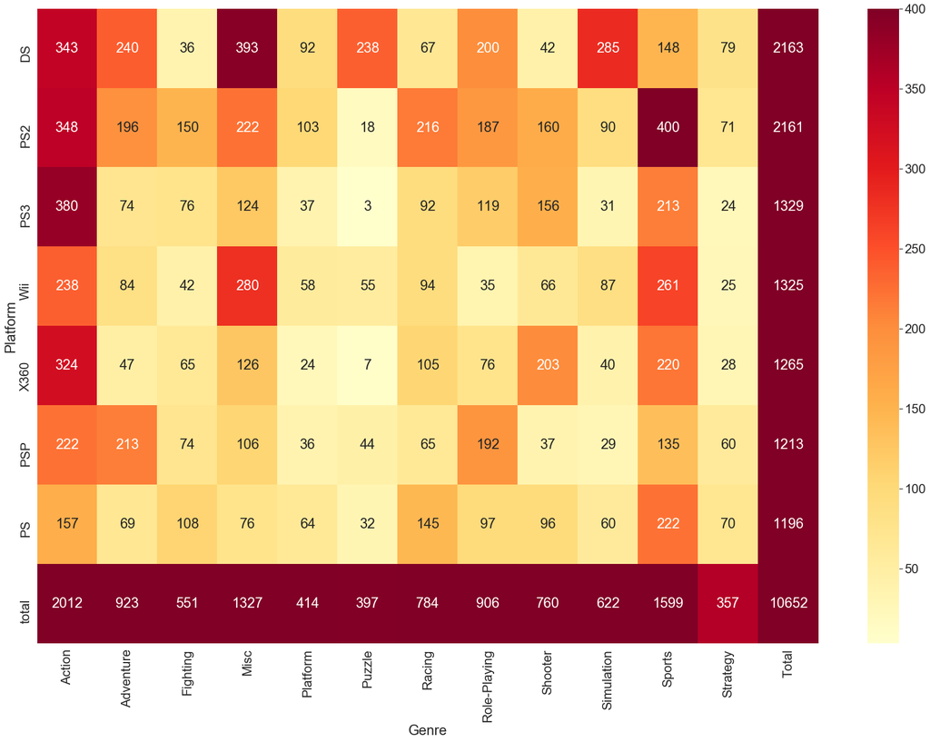

```python
platGenre['Total'] = platGenre.sum(axis=1)
popPlatform = platGenre[platGenre['Total']>1000].sort_values(by='Total', ascending = False)
neededdata = popPlatform.loc[:,:'Strategy']
maxi = neededdata.values.max()
mini = neededdata.values.min()
popPlatformfinal = popPlatform.append(pd.DataFrame(popPlatform.sum(), columns=['total']).T, ignore_index=False)
sns.set(font_scale=2)
plt.figure(figsize=(30, 20))
sns.heatmap(popPlatformfinal, vmin = mini, vmax = maxi, annot=True, fmt="d", cmap = "YlOrRd")
plt.xticks(rotation = 90)
plt.ylabel("Platform")
plt.show()
```

从上面的直方图和热力图可以看出PS3平台上的动作类游戏，DS平台上的音乐类游戏以及PS2平台上的运动类游戏是最受欢迎的。  
接下来我们看一下基于平台和游戏类型的全球销售额情况：

```python
trace1 = go.Bar(x=xaction.groupby("Platform")["Global_Sales"].sum().index,
                y=xaction.groupby("Platform")["Global_Sales"].sum().values,
                opacity=0.75, name="Action", marker=dict(color="rgb(119,172,238)"))
trace2 = go.Bar(x=xsports.groupby("Platform")["Global_Sales"].sum().index,
                y=xsports.groupby("Platform")["Global_Sales"].sum().values,
                opacity=0.75, name="Sports", marker=dict(color='rgb(21,90,174)'))
trace3 = go.Bar(x=xrace.groupby("Platform")["Global_Sales"].sum().index,
                y=xrace.groupby("Platform")["Global_Sales"].sum().values,
                opacity=0.75, name="Racing", marker=dict(color="rgb(156,245,163)"))
trace4 = go.Bar(x=xshooter.groupby("Platform")["Global_Sales"].sum().index,
                y=xshooter.groupby("Platform")["Global_Sales"].sum().values,
                opacity=0.75, name="Shooter", marker=dict(color="rgb(14,135,23)"))
trace5 = go.Bar(x=xmisc.groupby("Platform")["Global_Sales"].sum().index,
                y=xmisc.groupby("Platform")["Global_Sales"].sum().values,
                opacity=0.75, name="Misc", marker=dict(color='rgb(252,118,103)'))
trace6 = go.Bar(x=xrole.groupby("Platform")["Global_Sales"].sum().index,
                y=xrole.groupby("Platform")["Global_Sales"].sum().values,
                opacity=0.75, name="Role Playing", marker=dict(color="rgb(226,28,5)"))
trace7 = go.Bar(x=xfight.groupby("Platform")["Global_Sales"].sum().index,
                y=xfight.groupby("Platform")["Global_Sales"].sum().values,
                opacity=0.75, name="Fighting", marker=dict(color="rgb(247,173,13)"))
trace8 = go.Bar(x=xplatform.groupby("Platform")["Global_Sales"].sum().index,
                y=xplatform.groupby("Platform")["Global_Sales"].sum().values,
                opacity=0.75, name="Platform", marker=dict(color="rgb(242,122,13)"))
trace9 = go.Bar(x=xsimulation.groupby("Platform")["Global_Sales"].sum().index,
                y=xsimulation.groupby("Platform")["Global_Sales"].sum().values,
                opacity=0.75, name="Simulation", marker=dict(color="rgb(188,145,202)"))
trace10 = go.Bar(x=xadventure.groupby("Platform")["Global_Sales"].sum().index,
                 y=xadventure.groupby("Platform")["Global_Sales"].sum().values,
                 opacity=0.75, name="Adventure", marker=dict(color='rgb(104,57,119)'))
trace11 = go.Bar(x=xstrategy.groupby("Platform")["Global_Sales"].sum().index,
                 y=xstrategy.groupby("Platform")["Global_Sales"].sum().values,
                 opacity=0.75, name="Strategy", marker=dict(color='rgb(245,253,104)'))
trace12 = go.Bar(x=xpuzzle.groupby("Platform")["Global_Sales"].sum().index,
                 y=xpuzzle.groupby("Platform")["Global_Sales"].sum().values,
                 opacity=0.75, name="Puzzle", marker=dict(color='rgb(138,72,40)'))

data = [trace1, trace2, trace3, trace4, trace5, trace6, trace7, trace8, trace9, trace10, trace11, trace12]
layout = go.Layout(barmode='stack', title='Total Global Sales According to Platform and Genre',
                   xaxis=dict(title='Platform'), yaxis=dict( title='Global Sales(In Millions)'),
                   paper_bgcolor='beige', plot_bgcolor='beige'
)
fig = go.Figure(data=data, layout=layout)
iplot(fig)
```

[interactive chart not shown]

上图展示了数据集中按游戏类型和平台划分的全球销售总额。以Wii平台为例，全球共销售了29206万款体育游戏，X360的射击游戏销量为27855万款。

### **2.3. Genre and Region**

现在根据类型和地区来分析销售情况：  
首先我们来看一下不同类型的游戏的全球销售额：

```python
sales_by_genre = vgsales.groupby(['Genre','Name'], axis = 0).sum().reset_index()[['Genre', 'Name', 'Global_Sales']]
print(sales_by_genre.head(10))
genres = sales_by_genre.Genre.unique()
traces = []
c = ['hsl('+str(h)+',50%'+',50%)' for h in np.linspace(0, 360, len(genres))]

for i in range(len(genres)):
    genre = genres[i]
    df_genre = sales_by_genre[sales_by_genre.Genre == genre]
    trace = go.Box(y=np.array(df_genre.Global_Sales), name=genre, boxmean=True, marker={'color': c[i]})
    traces.append(trace)

layout = go.Layout(title='Global_Sales by Genre (Overall dataset)', showlegend=False,
                   yaxis=dict(title='Sales (in Millions)'), xaxis=dict(title='Genre'))

fig = go.Figure(data=traces, layout=layout)
iplot(fig)
```

```
    Genre                                               Name  Global_Sales
0  Action                  .hack: Sekai no Mukou ni + Versus          0.03
1  Action                             007: Quantum of Solace          3.92
2  Action                       007: The World is not Enough          2.47
3  Action                                   1001 Touch Games          0.33
4  Action  2 Games in 1 Double Pack: The Incredibles / Fi...          1.76
5  Action  2 Games in 1: Disney's Brother Bear / The Lion...          0.31
6  Action                                300: March to Glory          0.41
7  Action                                            3Xtreme          0.90
8  Action                3rd Super Robot Wars Z: Tengoku-Hen          0.34
9  Action                               50 Cent: Bulletproof          2.30
```

[interactive chart not shown]

接着我们单独来看看排名前100的不同类型的游戏在北美的销售额：

```python
df = vgsales.head(100)
sales_by_genre = df.groupby(['Genre', 'Name'], axis=0).sum().reset_index()[['Genre', 'Name', 'NA_Sales']]
print(sales_by_genre.head(10))
genres = sales_by_genre.Genre.unique()
traces = []
c = ['hsl('+str(h)+',50%'+',50%)' for h in np.linspace(0, 360, len(genres))]

for i in range(len(genres)):
    genre = genres[i]
    df_genre = sales_by_genre[sales_by_genre.Genre == genre]
    trace = go.Box(y=np.array(df_genre.NA_Sales), name=genre, boxmean=True, marker={'color': c[i]})
    traces.append(trace)

layout = go.Layout(title='NA_Sales by Genre (Top 100)', showlegend=False,
                   yaxis=dict(title='Sales (in Millions)'), xaxis=dict(title='Genre'))

fig = go.Figure(data=traces, layout=layout)
iplot(fig)
```

```
       Genre                                    Name  NA_Sales
0     Action                          FIFA Soccer 13      1.06
1     Action                    Grand Theft Auto III      6.99
2     Action                     Grand Theft Auto IV     11.52
3     Action                      Grand Theft Auto V     20.44
4     Action  Grand Theft Auto: Liberty City Stories      2.90
5     Action           Grand Theft Auto: San Andreas      9.43
6     Action             Grand Theft Auto: Vice City      8.41
7     Action    Pokemon HeartGold/Pokemon SoulSilver      4.40
8     Action    The Legend of Zelda: Ocarina of Time      4.10
9  Adventure      Super Mario Land 2: 6 Golden Coins      6.16
```

[interactive chart not shown]

为了能够直观的看到各个类型的游戏在不同地区的销售额的情况，将他们统计后放在一张图中：

```python
# 这里将Genre作为groupby依据，统计各类型游戏在各地区的销售额
genre = pd.DataFrame(vgsales.groupby("Genre")
                     [["NA_Sales", "EU_Sales", "JP_Sales", "Other_Sales", "Global_Sales"]].sum())
genre.reset_index(level=0, inplace=True)
genrecount = pd.DataFrame(vgsales["Genre"].value_counts())
genrecount.reset_index(level=0, inplace=True)
genrecount.rename(columns={"Genre": "Counts", "index": "Genre"}, inplace=True)

genre = pd.merge(genre, genrecount, on="Genre")
```

```python
table_data = genre[["Genre", "NA_Sales", "EU_Sales", "JP_Sales", "Other_Sales", "Global_Sales"]]
table_data = table_data.rename(columns = {"NA_Sales": "North America", "EU_Sales":"Europe",
                                  "JP_Sales": "Japan", "Other_Sales": "Other", "Global_Sales": "Total"})
```

```python
x = genre.Genre
# 计算不同类型游戏在各地区销售额占总销售额的百分比
NA_Perce = list(genre["NA_Sales"] / genre["Global_Sales"] * 100)
EU_Perce = list(genre["EU_Sales"] / genre["Global_Sales"] * 100)
JP_Perce=list(genre["JP_Sales"] / genre["Global_Sales"] * 100)
Other_Perce=list(genre["Other_Sales"] / genre["Global_Sales"] * 100)

# 画Bar图
trace1 = go.Bar(x=x, y=NA_Perce, name="North America" , xaxis='x2', yaxis='y2',
                marker=dict(color='rgb(158,202,225)', line=dict(color='rgb(8,48,107)', width=3)), opacity=0.75)
trace2 = go.Bar(x=x, y=EU_Perce, name="Europe", xaxis='x2', yaxis='y2',
                marker=dict(color='red', line=dict(color='rgb(8,48,107)',width=3)), opacity=0.75)
trace3 = go.Bar(x=x, y=JP_Perce, name="Japan", xaxis='x2', yaxis='y2',
                marker=dict(color='orange', line=dict(color='rgb(8,48,107)',width=3)), opacity=0.75)
trace4 = go.Bar(x=x, y=Other_Perce, name = "Other", xaxis='x2', yaxis='y2',
                marker=dict(color='purple', line=dict(color='rgb(8,48,107)',width=3)), opacity=0.75)

# 画表
trace5 = go.Table(
    header=dict(values=table_data.columns, line=dict(color='rgb(8,48,107)', width=3),
                  fill=dict(color=["darkslateblue", "blue", "red", "orange", "purple", "green"]),
                  align=['left','center'], font=dict(color='white', size=12), height=30,),
    cells=dict(values = [table_data.Genre, round(table_data["North America"]), round(table_data["Europe"]),
                         round(table_data["Japan"]), round(table_data["Other"]), round(table_data["Total"])],
                 height=30, line=dict(color='rgb(8,48,107)', width=3),
                 fill=dict(color=["silver", "rgb(158,202,225)", "darksalmon", "gold", "mediumorchid", "yellowgreen"]),
                 align=['left', 'center'], font=dict(color='#506784', size = 12)),
    domain=dict(x=[0.60, 1],y=[0, 0.95]))

data = [trace1, trace2, trace3, trace4, trace5]
layout = go.Layout(barmode='stack', autosize=False, width=1200, height=650,
                legend=dict(x=.58, y=0, orientation="h",
                            font=dict(family='Courier New, monospace', size=11, color='#000'),
                            bgcolor='beige', bordercolor='beige', borderwidth=1),
                title='North America, Europe, Japan and Other Sales Percentage and Amounts According to Genre',
                titlefont=dict(family='Courier New, monospace', size=17, color='black'),
                xaxis2=dict(domain=[0, 0.50], anchor="y2", title='Genre',
                            titlefont=dict(family='Courier New, monospace'),
                            tickfont=dict(family='Courier New, monospace')
                           ),
                yaxis2=dict(domain=[0, 1], anchor='x2', title="Total Percentage",
                            titlefont=dict(family='Courier New, monospace'),
                            tickfont=dict(family='Courier New, monospace')),
                paper_bgcolor='beige',plot_bgcolor='beige',
                annotations=[dict(text='Sales Percentage According to Region',
                                  x=0.08, y=1.02, xref="paper", yref="paper",
                                  showarrow=False, font=dict(size=15,family="Courier New, monospace"),
                                  bgcolor="lightyellow",borderwidth=5),
                             dict(text='Total Sales(In Millions)', x=0.9, y=1.02,
                                  xref="paper", yref="paper", showarrow=False,
                                  font=dict(size=15, family='Courier New, monospace'),
                                  bgcolor="lightyellow", borderwidth=5)])

fig = go.Figure(data=data, layout=layout)
iplot(fig)
```

[interactive chart not shown]

左边的图表向我们展示了不同地区的游戏类型百分比。例如，大约50%的动作类电影是在北美销售的，同时可以在右边的表中看到在北美销售的具体值。  
例如，模拟类型游戏的总销售额为3.92亿。其中6400万是在日本售出的。  
总体来看，当关注于游戏类型时，我们会发现：

- 北美地区的销售比例在44-56%之间（不包括角色扮演和策略类型的游戏），销售最多的类型是**射击游戏和平台游戏**。
- 在日本，主要销售的是**角色扮演类游戏**，而射击类游戏的销量低于其他地区。
- 在欧洲，整体看来各类游戏的销售额所占百分比较为平均，各类游戏都受到青睐。
- 在其他地区，销售额较多的游戏类型是**竞速、动作和运动**，并且各类游戏的销售额所占百分比都较小。

## **3. Sales Prediction**

### **3.1. Basic Import**

首先导入各类依赖包：

```python
from sklearn.preprocessing import LabelEncoder  # 编码
from sklearn.model_selection import train_test_split  # 对测试集和训练集进行划分

### 引入各种分类器的包
from sklearn.linear_model import LinearRegression  # 线性回归
from sklearn.ensemble import RandomForestClassifier  # 随机森林
from sklearn.neighbors import KNeighborsClassifier  # KNN
from sklearn import tree  # 决策树
from sklearn.svm import SVC # 支持向量机

### 评价方法
from sklearn.metrics import  r2_score, explained_variance_score
from sklearn.metrics import accuracy_score
```

### **3.2. Data Processing**

```python
# 读取数据
df = pd.DataFrame(pd.read_csv('vgsales.csv'))
df.head()
```

|  | Rank | Name | Platform | Year | Genre | Publisher | NA_Sales | EU_Sales | JP_Sales | Other_Sales | Global_Sales |
| --- | --- | --- | --- | --- | --- | --- | --- | --- | --- | --- | --- |
| 0 | 1 | Wii Sports | Wii | 2006.0 | Sports | Nintendo | 41.49 | 29.02 | 3.77 | 8.46 | 82.74 |
| 1 | 2 | Super Mario Bros. | NES | 1985.0 | Platform | Nintendo | 29.08 | 3.58 | 6.81 | 0.77 | 40.24 |
| 2 | 3 | Mario Kart Wii | Wii | 2008.0 | Racing | Nintendo | 15.85 | 12.88 | 3.79 | 3.31 | 35.82 |
| 3 | 4 | Wii Sports Resort | Wii | 2009.0 | Sports | Nintendo | 15.75 | 11.01 | 3.28 | 2.96 | 33.00 |
| 4 | 5 | Pokemon Red/Pokemon Blue | GB | 1996.0 | Role-Playing | Nintendo | 11.27 | 8.89 | 10.22 | 1.00 | 31.37 |

```python
# 查看数据各属性类型信息
df.info()
```

```
<class 'pandas.core.frame.DataFrame'>
RangeIndex: 16598 entries, 0 to 16597
Data columns (total 11 columns):
 #   Column        Non-Null Count  Dtype
---  ------        --------------  -----
 0   Rank          16598 non-null  int64
 1   Name          16598 non-null  object
 2   Platform      16598 non-null  object
 3   Year          16327 non-null  float64
 4   Genre         16598 non-null  object
 5   Publisher     16540 non-null  object
 6   NA_Sales      16598 non-null  float64
 7   EU_Sales      16598 non-null  float64
 8   JP_Sales      16598 non-null  float64
 9   Other_Sales   16598 non-null  float64
 10  Global_Sales  16598 non-null  float64
dtypes: float64(6), int64(1), object(4)
memory usage: 1.4+ MB
```

```python
# 查看数据集缺失值
df.isnull().sum()
```

```
Rank              0
Name              0
Platform          0
Year            271
Genre             0
Publisher        58
NA_Sales          0
EU_Sales          0
JP_Sales          0
Other_Sales       0
Global_Sales      0
dtype: int64
```

这里根据之前完成数据分析的方法，我们对数据集进行缺失值填充：

```python
# 这里采用年份平均数填充缺失的年份
def impute_median(series):
    return series.fillna(series.median())

df.Year = df['Year'].transform(impute_median)
```

```python
# 输出最多的游戏发布商
df['Publisher'].mode()
```

```
0    Electronic Arts
dtype: object
```

```python
# 这里采用发布商众数填充缺失的发布商
df['Publisher'].fillna(str(df['Publisher'].mode().values[0]), inplace=True)
```

```python
print(df.isnull().sum())
```

```
Rank            0
Name            0
Platform        0
Year            0
Genre           0
Publisher       0
NA_Sales        0
EU_Sales        0
JP_Sales        0
Other_Sales     0
Global_Sales    0
dtype: int64
```

```python
# 去除游戏发布年份超过2016年的数据
df = df[df.Year < 2016]
```

接着，对**所有属性**（这里之所以对全部属性进行编码，一方面考虑到编码的统一性，另一方面尝试如果只对标称属性编码，由于该数据集中**数值属性类型为float64**，后序在喂进模型分类时会报错，若是将其类型.astype(int)会损失精度，最终导致预测结果虚高）进行编码，将标签存储在内存中，稍后将使用这些标签单独从需要的特性和标签构建数据样式，利用标签编码所有分类标签

```python
categorical_labels = ['Rank', 'Name', 'Platform', 'Genre', 'Publisher']
numerical_labels = ['Year', 'NA_Sales', 'Other_Sales', 'Global_Sales']
enc = LabelEncoder()
encoded_df = pd.DataFrame(columns=['Rank', 'Name', 'Platform', 'Genre', 'Publisher',
                                   'Year', 'NA_Sales', 'Other_Sales', 'Global_Sales'])

for label in categorical_labels:
    temp_column = df[label]
    encoded_temp_col = enc.fit_transform(temp_column)
    encoded_df[label] = encoded_temp_col

for label in numerical_labels:
    temp_column = df[label]
    encoded_temp_col = enc.fit_transform(temp_column)
    encoded_df[label] = encoded_temp_col
```

```python
# 输出编码后的数据格式
encoded_df.head()
```

|  | Rank | Name | Platform | Genre | Publisher | Year | NA_Sales | Other_Sales | Global_Sales |
| --- | --- | --- | --- | --- | --- | --- | --- | --- | --- |
| 0 | 0 | 10820 | 26 | 10 | 351 | 26 | 408 | 155 | 621 |
| 1 | 1 | 9169 | 11 | 4 | 351 | 5 | 407 | 77 | 620 |
| 2 | 2 | 5479 | 26 | 6 | 351 | 28 | 404 | 152 | 619 |
| 3 | 3 | 10822 | 26 | 10 | 351 | 29 | 403 | 151 | 618 |
| 4 | 4 | 7226 | 5 | 7 | 351 | 16 | 397 | 96 | 617 |

可以看到所有的属性均进行编码，接下来我们对数据集进行切分，切分为训练集和测试集

```python
train, test = train_test_split(encoded_df, test_size=0.1, random_state=1)

def data_splitting(df):
    x = df.drop(['NA_Sales', 'Other_Sales', 'Global_Sales'], axis=1)
    y = df['Global_Sales']
    return x, y

x_train, y_train = data_splitting(train)
x_test, y_test = data_splitting(test)
```

对线性回归对模型进行评估，其中.score()函数返回的是线性回归模型的决定系数r^2，越接近1，表明方程的变量对y的解释能力越强，这个模型对数据拟合的也较好；越接近0，表明模型拟合的越差；一般认为：>0.4，说明模型的拟合效果好。但是数据集的样本越大，R²越大，因此，不同数据集的模型结果比较会有一定的误差。

```python
### 线性回归 LinearRegression
log = LinearRegression()
log.fit(x_train, y_train)

log_train = log.score(x_train, y_train)
log_test = log.score(x_test, y_test)

print("=" * 70)
print("Training score :", log_train)
print("Testing score :", log_test)
print("=" * 70)
```

```
======================================================================
Training score : 0.4424364185111336
Testing score : 0.4360433767854321
======================================================================
```

### **3.3. Different Classifier**

完成数据的基本处理后，我们将其喂入不同的分类器中然后对不同分类器进行评估：

**1、随机森林分类器 Random Forest Classifier**

```python
### 随机森林分类器 Random Forest Classifier
clf = RandomForestClassifier(n_estimators=8)
clf.fit(x_train, y_train)
clf_pred = clf.predict(x_test)
```

```python
# 对分类器进行评价
r2 = r2_score(y_test, clf_pred)
evs = explained_variance_score(y_test, clf_pred)

print(f'Random Forest R2 Coeff: {r2}')
print(f'Random Forest Explained_Variance_Score: {evs}')
print("Random Forest Test Accuracy is {:.2f}%".format(accuracy_score(y_test, clf_pred) * 100.0))
```

```
Random Forest R2 Coeff: 0.5391155431951842
Random Forest Explained_Variance_Score: 0.5507773299735268
Random Forest Test Accuracy is 47.57%
```

```python
print("=" * 70)
print("测试集—全球销售额 :", y_test.values)
print("预测-全球销售额:", clf_pred)
print("=" * 70)
```

```
======================================================================
测试集—全球销售额 : [  4 115 170 ...  56  15  69]
预测-全球销售额: [  4 120 295 ...  60  15  12]
======================================================================
```

**2、KNN Classifier**

```python
### KNN Classifier
clf = KNeighborsClassifier()
clf.fit(x_train, y_train)
clf_pred = clf.predict(x_test)
```

```python
# 对分类器进行评价
r2 = r2_score(y_test, clf_pred)
evs = explained_variance_score(y_test, clf_pred)

print(f'\nKNN R2 Coeff: {r2}')
print(f'KNN Explained_Variance_Score: {evs}')
print("KNN Test Accuracy is {:.2f}%".format(accuracy_score(y_test, clf_pred) * 100.0))
```

```
KNN R2 Coeff: 0.9719471910544135
KNN Explained_Variance_Score: 0.973135931281521
KNN Test Accuracy is 57.17%
```

```python
print("=" * 70)
print("测试集—全球销售额 :", y_test.values)
print("预测-全球销售额:", clf_pred)
print("=" * 70)
```

```
======================================================================
测试集—全球销售额 : [  4 115 170 ...  56  15  69]
预测-全球销售额: [  4 112 167 ...  57  16  70]
======================================================================
```

**3、Decision Tree Classifier**

```python
### 决策树Decision Tree Classifier
clf = tree.DecisionTreeClassifier()
clf.fit(x_train, y_train)
clf_pred = clf.predict(x_test)
```

```python
# 对分类器进行评价
r2 = r2_score(y_test, clf_pred)
evs = explained_variance_score(y_test, clf_pred)

print(f'\nDecision Tree R2 Coeff: {r2}')
print(f'Decision Tree Explained_Variance_Score: {evs}')
print("Decision Tree Test Accuracy is {:.2f}%".format(accuracy_score(y_test, clf_pred) * 100.0))
```

```
Decision Tree R2 Coeff: 0.999871957580687
Decision Tree Explained_Variance_Score: 0.9998720200768646
Decision Tree Test Accuracy is 94.71%
```

```python
print("=" * 70)
print("测试集—全球销售额 :", y_test.values)
print("预测-全球销售额:", clf_pred)
print("=" * 70)
```

```
======================================================================
测试集—全球销售额 : [  4 115 170 ...  56  15  69]
预测-全球销售额: [  4 115 171 ...  56  15  70]
======================================================================
```

**4、SVM Classifier**

```python
###  SVM Classifier
clf = SVC(kernel='rbf', probability=True)
clf.fit(x_train, y_train)
clf_pred = clf.predict(x_test)
```

```python
# 对分类器进行评价
r2 = r2_score(y_test, clf_pred)
evs = explained_variance_score(y_test, clf_pred)

print(f'\nSVM R2 Coeff: {r2}')
print(f'SVM Explained_Variance_Score: {evs}')
print("SVM Test Accuracy is {:.2f}%".format(accuracy_score(y_test, clf_pred) * 100.0))
```

```
SVM R2 Coeff: 0.2668618620517479
SVM Explained_Variance_Score: 0.3392408535381578
SVM Test Accuracy is 44.80%
```

```python
print("=" * 70)
print("测试集—全球销售额 :", y_test.values)
print("预测-全球销售额:", clf_pred)
print("=" * 70)
```

```
======================================================================
测试集—全球销售额 : [  4 115 170 ...  56  15  69]
预测-全球销售额: [ 4 57 74 ... 44 15 50]
======================================================================
```